# COMPUTATIONAL MODELING OF THE ELECTRON TRANSPORT IN NANOSTRUCTURES

# Recursive relation of Chebyshev polynomials}

**Goal**: Evaluate $\mu_n$,

$\begin{align} \mu_n = {\rm Tr} \bigg\{ T_n\big[ \mathcal{H}(\vec{k}) \big]\bigg\} \end{align}$

We wil use the recursive relation,

$ \begin{align} T_0(\mathcal{H}) &= \mathcal{I}\\ T_1(\mathcal{H}) &= \mathcal{H}\\ T_n(\mathcal{H}) &= 2\mathcal{H}T_{m-1}(\mathcal{H})-T_{m-2}(\mathcal{H}) \end{align} $

and the stochastic evaluation of traces,

$ \begin{align} {\rm Tr} \approx \frac{1}{R} \sum_{r=0}^{R-1} \langle r | T_n(\mathcal{H})|r\rangle \end{align} $

```python
a1  = np.array([np.sqrt(3),0])
a2  = np.array([np.sqrt(3)/2,3/2])

M    = np.array( [[a1[0],a1[1]],[a2[0],a2[1]]] )
Minv = 2*pi*np.linalg.inv(M)
b1  = np.array( [ Minv[(0,0)],Minv[(1,0)] ] )
b2  = np.array( [ Minv[(0,1)],Minv[(1,1)] ] )

ngrid = 1000
X,Y   = np.meshgrid(linspace(0,1,ngrid),linspace(0,1,ngrid))
KX    = X*b1[0]+Y*b2[0]
KY    = X*b1[1]+Y*b2[1]

KX = KX.reshape(ngrid*ngrid,)
KY = KY.reshape(ngrid*ngrid,)

α  = 1.0+ np.exp( -1.J*(KX*a1[0]+KY*a1[1]) )+np.exp( -1.J*(KX*a2[0]+KY*a2[1]) )
αc = 1.0+ np.exp(  1.J*(KX*a1[0]+KY*a1[1]) )+np.exp(  1.J*(KX*a2[0]+KY*a2[1]) )
E  = α*αc
E  = np.sqrt(E.real)
E /= 3.1        # Energy range between -1 to 1
```

```python
%%time

nMom  = 100
mu = []
for i in range(nMom):
    c    = np.zeros(nMom)
    c[i] = 1
    Tnpos = np.polynomial.chebyshev.chebval( E.real,c)
    Tnneg = np.polynomial.chebyshev.chebval(-E.real,c)
    mu.append( Tnpos.sum() + Tnneg.sum() )

mu     = np.array(mu)
mu    /= ngrid*ngrid
mu    *= 2.0
mu[0] /= 2

# Jackson Kernel
n     = arange(nMom)
g     = ( (nMom-n+1.0)*cos(pi*n/(nMom+1.0))+sin(pi*n/(nMom+1.0))/tan(pi/(nMom+1.0)) )/( nMom+1.0 )
mubar = g*mu
```

```
CPU times: user 56.5 s, sys: 451 ms, total: 57 s
Wall time: 57 s
```

```python
%%time
nE       = 2000
Emubar   = linspace(-0.95,0.95,num=nE,endpoint=True)
DOSmubar = np.polynomial.chebyshev.chebval(Emubar,mubar)/pi/sqrt(1.0-Emubar*Emubar)
```

```
CPU times: user 1.85 ms, sys: 65 µs, total: 1.92 ms
Wall time: 1.39 ms
```

```python
%%time
nE  = 2000
E   = linspace(-0.95,0.95,num=nE,endpoint=True)
DOS = np.polynomial.chebyshev.chebval(E,mu)/pi/sqrt(1.0-E*E)
```

```
CPU times: user 1.43 ms, sys: 0 ns, total: 1.43 ms
Wall time: 1.17 ms
```

```
CPU times: user 333 ms, sys: 164 ms, total: 498 ms
Wall time: 193 ms
```

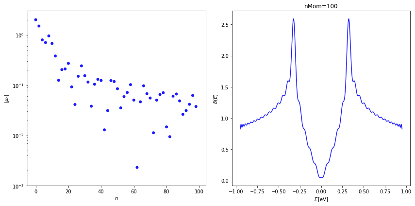

```python
%%time
fig, axes = plt.subplots(nrows=1, ncols=2, figsize=(12.0,6.0))

plt.title(r"nMom={0}".format(nMom))

axes[0].scatter(np.arange(nMom),np.abs(mu),marker="o",c="blue",alpha=0.9,edgecolor="none")
axes[0].set_ylabel(r"$|\mu_n|$")
axes[0].set_xlabel(r"$n$")
axes[0].set_ylim(10e-4,3)
axes[0].set_yscale("log",nonposy='clip')


axes[1].plot(E,DOS,'-',color="blue",alpha=0.9)
axes[1].set_ylabel(r"$\delta(E)$")
axes[1].set_xlabel(r"$E\,[{\rm eV}]$")
fig.tight_layout()
```

# Density of states of large real space graphene sample

### Recursive relation of Chebyshev polynomials

**Goal**: Evaluate $\mu_n$,

$\begin{align} \mu_n = {\rm Tr} \bigg\{ T_n\big[ \mathcal{H}(\vec{k}) \big]\bigg\} \end{align}$

We wil use the recursive relation,

$ \begin{align} T_0(\mathcal{H}) &= \mathcal{I}\\ T_1(\mathcal{H}) &= \mathcal{H}\\ T_n(\mathcal{H}) &= 2\mathcal{H}T_{m-1}(\mathcal{H})-T_{m-2}(\mathcal{H}) \end{align} $

and the stochastic evaluation of traces,

$ \begin{align} {\rm Tr}\bigg\{ T_n\big[ \mathcal{H}(\vec{k}) \big]\bigg\} \approx \frac{1}{R} \sum_{r=0}^{R-1} \langle r | T_n(\mathcal{H})|r\rangle \end{align} $

**Algorithm**: recursive relation of Chebyshev polynomials.

$ \begin{align} |r_0\rangle &= T_0(\mathcal{H}) |\Psi_{\rm rand}\rangle = |\Psi_{\rm rand}\rangle &\\ |r_1\rangle &= T_1(\mathcal{H}) |r_0 \rangle = \mathcal{H}|\Psi_{\rm rand}\rangle &\\ |r_2\rangle &= T_2(\mathcal{H}) |r_0\rangle = 2\mathcal{H}T_1|r_0\rangle-T_0(\mathcal{H})|r_0\rangle=2H|r_1\rangle+|r_0\rangle & \\ |r_3\rangle &= T_3(\mathcal{H}) |r_0\rangle = 2\mathcal{H}T_2|r_0\rangle-T_1(\mathcal{H})|r_0\rangle=2H|r_2\rangle+|r_1\rangle & \\ \vdots \\ |r_n\rangle &= T_n(\mathcal{H}) |r_0\rangle = 2\mathcal{H}T_{n-1}|r_0\rangle-T_{n-2}(\mathcal{H})|r_0\rangle=2H|r_{n-1}\rangle+|r_{n-2}\rangle & \end{align} $

```python
# Load moments
```

[output not shown]

# Thumb rule

$ \begin{align} \bigg|\,f(E)-f_{\rm KPM}\,\bigg| \propto \frac{1}{\sqrt{N}} \end{align} $

# Kubo-Greenwood formula

### Linear response

$ \begin{align} \langle j_x(0),j_x(t) \rangle \longrightarrow \sigma_{xx}=\frac{2\pi e^2\hbar^2}{\Omega} {\rm Tr} \bigg\{ \hat{V}_x \delta(E-\mathcal{H}) \hat{V}_x \delta(E-\mathcal{H}) \bigg\} \end{align} $

where $\hat{V}_x=[\hat{X},\mathcal{H}]/i\hbar$

$ \begin{align} \delta(E-\mathcal{H}) \end{align} $

$ \begin{align} \sigma(E) = \frac{4e^2\hbar }{\pi\Omega} \sum_{n=0}^{\mathcal{N}-1} \sum_{m=0}^{\mathcal{M}-1} \mathcal{T}_{mn}(E)\, \mu_{mn}\,, \end{align} $

where

$ \begin{align} \mu_{mn} &= {\rm Tr}\bigg\{ \hat{v}_x T_n(\hat{h}) \hat{v}_x T_m(\hat{h}) \bigg\}\\ \mu_{mn} &= {\rm Tr}\bigg\{ \frac{a_{\rm cutoff}}{ \hbar} [\hat{h},\mathcal{X}]\, T_n(\hat{h}) \frac{a_{\rm cutoff}}{\hbar} [\hat{h},\mathcal{X}]\, T_m(\hat{h}) \bigg\} \end{align} $

using $\hat{h} = \mathcal{H}/W$ ($W$ half-bandwidth) and $\mathcal{X}=X/a_{\rm cutoff}$. $T_n$ are the Chebyshev polynomials. Therefore,

$ \begin{align} \sigma(E) = \frac{4e^2}{\pi h} \bigg( \frac{4\pi}{3\sqrt{3}}\frac{a_{\rm cutoff}^2}{a_{\rm CC}^2} \bigg) \sum_{n=0}^{\mathcal{N}-1} \sum_{m=0}^{\mathcal{M}-1} \mathcal{T}_{mn}(E)\, {\rm Tr}\bigg\{ [\hat{h},\mathcal{X}]\, T_n(\hat{h}) [\hat{h},\mathcal{X}]\, T_m(\hat{h}) \bigg\}\,. \end{align} $

The different energy expansion are,

$ \begin{align} &{\rm CPGF:}\quad \mathcal{T}_{mn}(z=E+i\lambda) &=& {\rm Im}\bigg[ \frac{-2i}{1+\delta n0}\frac{(z-i\sqrt{1-z^2})^n}{\sqrt{1-z^2}}\bigg] {\rm Im}\bigg[ \frac{-2i}{1+\delta m0}\frac{(z-i\sqrt{1-z^2})^m}{\sqrt{1-z^2}} \bigg]\,,\\ &{\rm KPM:}\quad\,\, \mathcal{T}_{mn}(E) &=& \frac{g_n T_n(E) g_m T_m(E)}{1-E^2} \end{align} $

Lorentz Kernel:

$ \begin{align} g_n = \frac{ \sinh(\lambda (1-n/\mathcal{N}) }{\sinh(\lambda)}\,. \end{align} $

# Final remarks